# SEM: Structural Equation Modeling

Equipo 3

March 15, 2017

## Ecuaciones Estructurales

### Introducción

Los orígenes de los modelos de ecuaciones estructurales (SEM) se encuentran en las técnicas desarrollado hace 90 años por Stewal Wright (Wright 1921), que lo desarrollo en el campo de la genética, cuyo propósito fue el de permitir “el examen de un conjunto de relaciones entre una o más variables independientes, sean estas continuas o discretas” desarrollando una forma de romper las correlaciones observadas en un sistema de ecuaciones matemáticas que describían sus hipótesis respecto a unas relaciones causales. Estas relaciones entre las variables fueron representadas en un “path diagram”, conociéndose este método como “path analysis”.

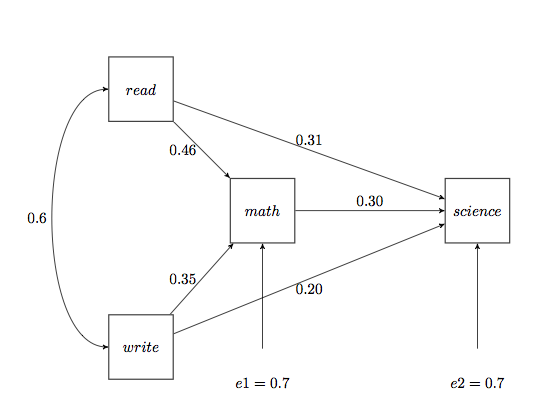

Los modelos de análisis factorial de confirmación son ejemplos relativamente simples de un marco más general para modelar variables latentes y se conocen como modelos de ecuación estructural o modelos de estructura de covarianza. En estos modelos, se asume nuevamente que las variables observadas son indicadores de las variables latentes subyacentes, pero ahora se incorporan las ecuaciones de regresión que enlazan las variables latentes.

El objetivo de las ecuaciones estructurales es explicar las correlaciones o covarianzas de las variables observadas en términos de las relaciones de estas variables con las variables latentes subyacentes asumidas y las relaciones postuladas entre las mismas variables latentes.

### Modelo

Este ejemplo muestra cómo estimas un modelo de ecuaciones estructurales (SEM), usando el paquete `sem` y el paquete `lavaan` de R.

Este modelo de ecuaciones estructurales consiste en dos modelos de medición, uno de inteligencia y otro del sentido del humor. Se supone que la inteligencia es una variable latente que pude medirse con los resultados de las pruebas en cuatro áreas: lectura, escritura, matemáticas y análisis. Se supone que el humor es una variable latente que se puede medir por lo mucho que uno disfruta ver los programas: *“The Simpsons,” “American Dad,” and “Family Guy.”* El modelo también consiste en un consiste en conectar la inteligencia con el humor.

### Ejemplo

```r
# 0. Librerías
library(tidyverse)
library(forcats)
library(foreign)
library(qgraph)
library(sem)
library(lavaan)
library(semPlot)
theme_set(theme_bw())
```

Los datos se leen de un servidor de [methods consultants](https://www.methodsconsultants.com) los datos están en formato PASW (SPSS).

```r
# 1. Datos
data <- read.spss("http://www.methodsconsultants.com/data/intelligence.sav",
                  to.data.frame=TRUE)
head(data)
```

```
##   reading writing  math analytic simpsons familyguy amerdad
## 1    0.39    0.17  0.21     0.73    -1.08     -0.56   -1.39
## 2    0.32    1.18  0.66    -0.25     0.84      0.86    0.68
## 3    0.22   -0.44  0.44     0.14    -0.73     -0.83   -0.49
## 4    0.17    0.66 -0.29    -0.13    -0.18      0.35   -0.04
## 5    1.34    1.12  0.97    -0.03    -0.27      0.01   -0.06
## 6    1.40    0.54  0.31     0.66     1.29      0.95    1.10
```

Las ecuaciones estructurales se estiman usalmente usando la matriz de covarianza de las observaciones.

Realizamos un analisis exploratorio de la covarianza entre las variables del modelo y se observa que se forman dos grupos uno de los programas “The Simpsons,” “American Dad,” and “Family Guy.” y otro de inteligencia lectura, escritura, matemáticas y análisis. Las variables con mayor coarianza entre ellas son mateáticas con lectura.

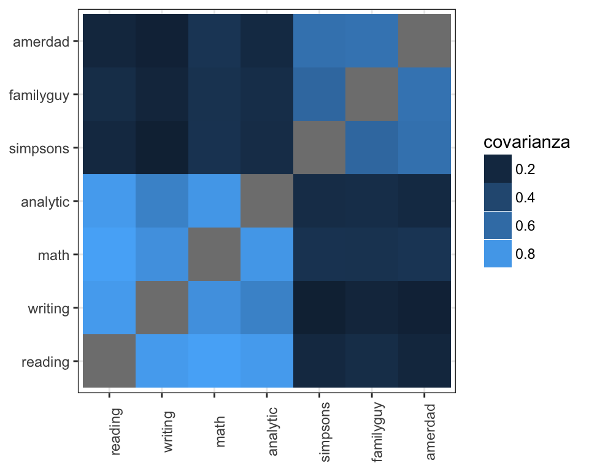

```r
data.cov <- cov(data)
data.cov %>%
  as_tibble() %>%
  mutate(nom = rownames(data.cov)) %>%
  gather(var.lab, var.val, -nom) %>%
  mutate(var.val2 = ifelse(var.lab == nom, NA, var.val),
         nom = factor(nom, levels = c('reading', 'writing', 'math',
                                      'analytic', 'simpsons',
                                      'familyguy',  'amerdad')),
         var.lab = factor(var.lab, levels = c('reading', 'writing', 'math',
                                      'analytic', 'simpsons',
                                      'familyguy',  'amerdad'))) %>%
  ggplot(aes(x = nom, y = var.lab, fill = var.val2)) +
  geom_tile() +
  ylab(NULL) + xlab(NULL) +
  theme(axis.text.x = element_text(angle = 90)) +
  guides(fill = guide_legend("covarianza"))
```

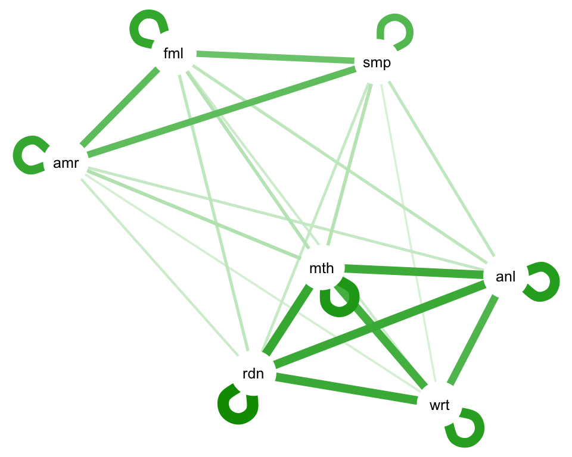

```r
qgraph(cov(data), borders = FALSE, layout = "spring")
```

#### Librería SEM

##### Especificación del modelo

El usario especifica el modelo, ya sea directo en R o desde un `.txt`. La sintaxis para `sem::specifyModel()` es la siguiente:

- La primera entrada es la relación entre variables. Cuando se usa `->` se indica que es un coeficiente de regresión y cuando se usa `<->` representa la varianza o covarianza.
- La segunda entrada es un nombre aleatorio que se la da al parámetro que se va a estatimar. Al introducir `NA` se indica que al parámetro se le da un valor en específico.
- La tercera entrada es el valor incial o el valor especifico de los parámetros.

Un vez que se tiene el modelo y la matriz de covarianza se usa la función `sem::sem(modelo, matriz, número de observaciones)`.

```r
# 3. librería SEM
cat(file = "sem_intellect.txt",
"humor -> simpsons, NA, 1
humor -> familyguy, l2, NA
humor -> amerdad, l3, NA
intell -> reading, l4, NA
intell -> writing, l5, NA
intell -> math, l6, NA
intell -> analytic, l7, NA
intell -> humor, g1, NA
simpsons <-> simpsons, e1, NA
familyguy <-> familyguy, e2, NA
amerdad <-> amerdad, e3, NA
reading <-> reading, d1, NA
writing <-> writing, d2, NA
math <-> math, d3, NA
analytic <-> analytic, d4, NA
intell <-> intell, NA, 1
humor <-> humor, z1, NA")

specify.sem <- sem::specifyModel(file = "sem_intellect.txt")
fit.sem <- sem::sem(specify.sem, data.cov, N = 100)
summary(fit.sem)
```

```
##
##  Model Chisquare =  13.67829   Df =  13 Pr(>Chisq) = 0.3968841
##  AIC =  43.67829
##  BIC =  -46.18892
##
##  Normalized Residuals
##       Min.    1st Qu.     Median       Mean    3rd Qu.       Max.
## -0.7649000 -0.1593000  0.0000023 -0.0156900  0.0798100  0.6619000
##
##  R-square for Endogenous Variables
##     humor  simpsons familyguy   amerdad   reading   writing      math
##    0.1020    0.8304    0.6921    0.8202    0.7956    0.7621    0.8373
##  analytic
##    0.7859
##
##  Parameter Estimates
##    Estimate  Std Error  z value   Pr(>|z|)
## l2 1.0150917 0.09052978 11.212794 3.528766e-29 familyguy <--- humor
## l3 1.0995754 0.08584468 12.808895 1.462026e-37 amerdad <--- humor
## l4 0.9426924 0.08385626 11.241765 2.542483e-29 reading <--- intell
## l5 0.8426412 0.07767021 10.848963 2.017004e-27 writing <--- intell
## l6 0.9128749 0.07777272 11.737725 8.165321e-32 math <--- intell
## l7 0.8636475 0.07761684 11.127064 9.263698e-29 analytic <--- intell
## g1 0.2417031 0.08025549  3.011671 2.598140e-03 humor <--- intell
## e1 0.1169712 0.03192547  3.663884 2.484190e-04 simpsons <--> simpsons
## e2 0.2625277 0.04690134  5.597447 2.175319e-08 familyguy <--> familyguy
## e3 0.1518445 0.03940479  3.853454 1.164634e-04 amerdad <--> amerdad
## d1 0.2282714 0.04356889  5.239321 1.611683e-07 reading <--> reading
## d2 0.2216015 0.03979111  5.569122 2.560265e-08 writing <--> writing
## d3 0.1619639 0.03477510  4.657468 3.201227e-06 math <--> math
## d4 0.2032079 0.03801093  5.346040 8.989955e-08 analytic <--> analytic
## z1 0.5143115 0.09128566  5.634088 1.759870e-08 humor <--> humor
##
##  Iterations =  35
```

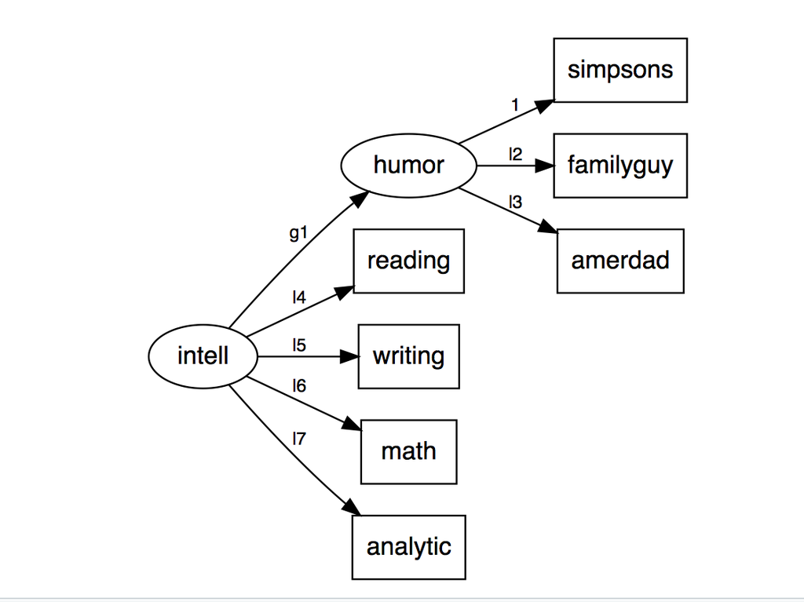

```r
pathDiagram(fit.sem)
```

#### Librería Lavaan

En `lavaan` no se necesita la función que especifica al modelo aunque si se debe especificar un modelo y la forma de hacerlo es la siguiente:

- El operador `=~` define las variables latentes
- El operador `~` define una regresión
- El operador `~~` indica correlación

Un vez que se tiene el modelo y la matriz de covarianza se usa la función `lavaan::sem(modelo, matriz)`.

```r
model <- "
# latent variable definitions
humor =~ simpsons + familyguy + amerdad
intell =~ reading + writing + math + analytic
# regressions
intell ~ humor
"

fit.lav <- lavaan::sem(model, data = data)
lavaan::summary(fit.lav, standardized=TRUE)
```

```
## lavaan (0.5-23.1097) converged normally after  31 iterations
##
##   Number of observations                           100
##
##   Estimator                                         ML
##   Minimum Function Test Statistic               13.816
##   Degrees of freedom                                13
##   P-value (Chi-square)                           0.387
##
## Parameter Estimates:
##
##   Information                                 Expected
##   Standard Errors                             Standard
##
## Latent Variables:
##                    Estimate  Std.Err  z-value  P(>|z|)   Std.lv  Std.all
##   humor =~
##     simpsons          1.000                               0.753    0.911
##     familyguy         1.015    0.090   11.269    0.000    0.764    0.832
##     amerdad           1.100    0.085   12.873    0.000    0.828    0.906
##   intell =~
##     reading           1.000                               0.938    0.892
##     writing           0.894    0.071   12.573    0.000    0.838    0.873
##     math              0.968    0.070   13.928    0.000    0.908    0.915
##     analytic          0.916    0.070   12.998    0.000    0.859    0.887
##
## Regressions:
##                    Estimate  Std.Err  z-value  P(>|z|)   Std.lv  Std.all
##   intell ~
##     humor             0.398    0.130    3.054    0.002    0.319    0.319
##
## Variances:
##                    Estimate  Std.Err  z-value  P(>|z|)   Std.lv  Std.all
##    .simpsons          0.116    0.031    3.682    0.000    0.116    0.170
##    .familyguy         0.260    0.046    5.626    0.000    0.260    0.308
##    .amerdad           0.150    0.039    3.873    0.000    0.150    0.180
##    .reading           0.226    0.043    5.266    0.000    0.226    0.204
##    .writing           0.219    0.039    5.597    0.000    0.219    0.238
##    .math              0.160    0.034    4.681    0.000    0.160    0.163
##    .analytic          0.201    0.037    5.373    0.000    0.201    0.214
##     humor             0.567    0.099    5.734    0.000    1.000    1.000
##    .intell            0.790    0.141    5.585    0.000    0.898    0.898
```

```r
lavaan::coef(fit.lav) %>% sort()
```

```
##   simpsons~~simpsons     amerdad~~amerdad           math~~math
##            0.1158016            0.1503261            0.1603443
##   analytic~~analytic     writing~~writing     reading~~reading
##            0.2011759            0.2193856            0.2259887
## familyguy~~familyguy         intell~humor         humor~~humor
##            0.2599026            0.3978334            0.5670045
##       intell~~intell      intell=~writing     intell=~analytic
##            0.7900421            0.8938661            0.9161496
##         intell=~math     humor=~familyguy       humor=~amerdad
##            0.9683696            1.0150918            1.0995754
```

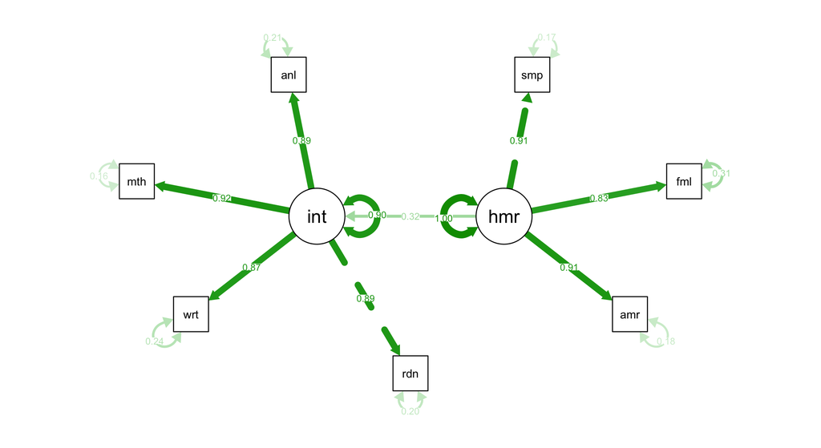

```r
semPaths(fit.lav, "std", curvePivot = T, layout = "circle2")
```

```r
lavaan::modindices(fit.lav)
```

```
##          lhs op       rhs    mi    epc sepc.lv sepc.all sepc.nox
## 18     humor =~   reading 0.848 -0.074  -0.056   -0.053   -0.053
## 19     humor =~   writing 3.133 -0.137  -0.103   -0.107   -0.107
## 20     humor =~      math 4.224  0.148   0.111    0.112    0.112
## 21     humor =~  analytic 0.121  0.026   0.020    0.020    0.020
## 22    intell =~  simpsons 0.075  0.015   0.014    0.016    0.016
## 23    intell =~ familyguy 0.228  0.032   0.030    0.032    0.032
## 24    intell =~   amerdad 0.445 -0.039  -0.037   -0.040   -0.040
## 25  simpsons ~~ familyguy 0.445 -0.072  -0.072   -0.095   -0.095
## 26  simpsons ~~   amerdad 0.228  0.068   0.068    0.091    0.091
## 27  simpsons ~~   reading 0.014  0.003   0.003    0.003    0.003
## 28  simpsons ~~   writing 2.236 -0.034  -0.034   -0.042   -0.042
## 29  simpsons ~~      math 0.298  0.011   0.011    0.014    0.014
## 30  simpsons ~~  analytic 0.723  0.019   0.019    0.023    0.023
## 31 familyguy ~~   amerdad 0.075  0.032   0.032    0.038    0.038
## 32 familyguy ~~   reading 0.561  0.023   0.023    0.024    0.024
## 33 familyguy ~~   writing 0.287  0.016   0.016    0.018    0.018
## 34 familyguy ~~      math 0.973 -0.027  -0.027   -0.029   -0.029
## 35 familyguy ~~  analytic 0.012  0.003   0.003    0.003    0.003
## 36   amerdad ~~   reading 1.555 -0.033  -0.033   -0.034   -0.034
## 37   amerdad ~~   writing 0.004  0.002   0.002    0.002    0.002
## 38   amerdad ~~      math 1.999  0.033   0.033    0.036    0.036
## 39   amerdad ~~  analytic 0.559 -0.018  -0.018   -0.021   -0.021
## 40   reading ~~   writing 2.862  0.059   0.059    0.058    0.058
## 41   reading ~~      math 3.423 -0.070  -0.070   -0.067   -0.067
## 42   reading ~~  analytic 0.148  0.014   0.014    0.013    0.013
## 43   writing ~~      math 0.059  0.008   0.008    0.009    0.009
## 44   writing ~~  analytic 2.378 -0.049  -0.049   -0.053   -0.053
## 45      math ~~  analytic 1.125  0.037   0.037    0.038    0.038
```

En `levaan` no es necesario dar nombre a los parámetros ni especificar la varianza.

### Referencias

- http://www-personal.umich.edu/~gonzo/papers/sem.pdf
- http://masteres.ugr.es/moea/pages/curso201314/tfm1314/tfm-septiembre1314/memoriamasterantonio_lara_hormigo/!
- https://www.methodsconsultants.com/tutorial/structural-equation-models-using-the-sem-package-in-r/